# Wage Prediction

Elia Aeby

2024-05-22

# 1 First Preparation

## 1.1 Loading the required libraries

To solve the wage prediction group work we used the following libraries.

```r
library(e1071)
library(tidyverse)
library(dlookr)
library(caret)
library(rsample)
library(rpart)
library(rpart.plot)
library(randomForest)
library(finalfit)
library(patchwork)
library(nnet)
library(xgboost)
library(mltools)
library(reshape2)
library(pracma)
library(PRROC)
library(pROC)
library(ROCR)
library(nnet)
library(neuralnet)
library(Boruta)
library(readxl)
library(SHAPforxgboost)
library(shapviz)
library(ggplot2)
library(shapper)
library(data.table)
set.seed(123) # Set random seed to make results reproducible
```

## 1.2 Import the Data

```r
load("data_wage.RData")

# Copying the data for safety
data_wage <- data
```

# 2 Understanding the Data Set

The initial step in our analysis is to thoroughly understand the available data by examining various statistical key figures and creating diverse visualizations. This also allows us to assess the quality of the data. Utilizing the ‘overview’ function reveals that our dataset comprises 10,809 observations and 78 different variables. Notably, the dataset is complete with no missing observations, variables, or values, and there are no duplicate entries, indicating high data quality.

```r
# To get an overview of the data
overview(data)
```

```
##      division               metrics   value
## 1        size          observations   10809
## 2        size             variables      78
## 3        size                values  843102
## 4        size           memory size 6216520
## 5  duplicated duplicate observation       0
## 6     missing  complete observation   10809
## 7     missing   missing observation       0
## 8     missing     missing variables       0
## 9     missing        missing values       0
## 10  data type              numerics      64
## 11  data type              integers       0
## 12  data type       factors/ordered      14
## 13  data type            characters       0
## 14  data type                 Dates       0
## 15  data type              POSIXcts       0
## 16  data type                others       0
```

The analysis highlights that 64 out of the 78 variables are classified as numeric, primarily due to one-hot encoding, which converts categorical variables into binary ones. Each of these binary variables represents a category, with a value of 1 indicating the presence of the category and 0 indicating its absence. This conversion explains the high number of numeric variables in the dataset.

To understand the data that we are working with even further, let’s have a look at the variables.

# 3 Survey Demographics and Insights

## 3.1 Gender and Age Distribution

The survey data reveals a significant gender disparity, with notably more men (9,135) participating compared to women (1,571). Additionally, the age distribution shows that most respondents are between 25 and 29 years old.

## 3.2 Geographic and Educational Background

Geographically, the majority of participants are from the United States (2,505), followed by India (1,576) and China (563). In terms of education, the dataset indicates a high level of academic achievement, with the majority holding a Master’s degree (5,209), followed by Bachelor’s degrees (2,990) and doctorates (1,869). This suggests a well-educated respondent pool.

## 3.3 Professional Background and Technical Skills

The most common undergraduate majors are computer science (4,239) and engineering (1,704), highlighting a strong technical background among respondents. Predominant job roles include Data Scientist (2,505) and Software Engineer (1,800), further underscoring the technical nature of their work. The most represented industries are computer technology (3,032) and education (1,317). Most participants have between 0 to 1 years (2,604) and 1 to 2 years (1,974) of experience, indicating relatively recent entry into the workforce.

## 3.4 Machine Learning and Coding Proficiency

Regarding machine learning, the majority of respondents are either gradually integrating ML methods into their work or are just beginning this process. A significant number of participants spend 50% to 74% of their time coding (3,458). Many have 1-2 years (3,030) and 3-5 years (2,700) of experience in coding for data analysis. Additionally, a large portion has less than 1 year of experience using ML methods (3,306), indicating a growing interest. Most respondents identify themselves as data scientists with a high degree of confidence. Python emerges as the most frequently used programming language (5,754), followed by R (1,500) and SQL (973), reflecting their central role in data science.

## 3.5 One Hot Encoding

Now that we know a lot more about our data we use one hot encoding to start working with the data.

# 4 Key Insights from Survey Data

## 4.1 Important Work Activities

The survey indicates that the majority of respondents focus on analyzing data to support business decisions, underscoring the critical role of data comprehension in professional settings. Additionally, the development and maintenance of machine learning services and data infrastructures are essential tasks, highlighting the practical application of ML in operations. While innovative activities such as prototyping and research in machine learning are less common, they remain significant for a notable portion of respondents.

## 4.2 Tools and Technologies

Kaggle Kernels is the most frequently used notebook platform, with 3,605 mentions, followed by JupyterHub Binder (2,998 mentions) and Google Colab (2,101 mentions). This popularity points to the convenience and integrated tools these platforms offer. However, a substantial number of respondents (4,103) reported not using any of the listed hosted notebooks. Regarding cloud computing services, Amazon Web Services (AWS) leads with 4,968 mentions, followed by Google Cloud Platform (GCP) with 2,979 mentions and Microsoft Azure with 2,517 mentions, though 3,469 respondents had not used any cloud services in the past five years.

## 4.3 Programming and Machine Learning

Python stands out as the most commonly used programming language, with 9,547 mentions, emphasizing its dominance in the tech industry. SQL (5,921 mentions) and R (4,548 mentions) are also widely used, reflecting their importance in data manipulation and statistical analysis. In machine learning frameworks, Scikit-Learn is the most utilized (7,588 mentions), followed by TensorFlow (6,162 mentions) and Keras (5,060 mentions). The high usage of Xgboost (3,586 mentions) and RandomForest (3,764 mentions) underscores the popularity of decision tree frameworks.

## 4.4 Data Visualization and Types

Matplotlib is the most used data visualization tool with 8,101 mentions, followed by ggplot2 (5,122 mentions) and Plotly (3,710 mentions). Shiny, for building interactive web applications from R, had 1,921 mentions. The majority of respondents work with numerical data (6,850 mentions) and textual data (5,428 mentions). Time series data is also popular (5,079 mentions), and categorical data was mentioned by 5,213 respondents, indicating its widespread use for classification and grouping.

## 4.5 Methods for Interpreting ML Models

Examining the importance of features is the preferred method for explaining ML model decisions, with 4,021 responses, highlighting its value in understanding model behavior. Exploring feature correlations (3,642 mentions) is also important, while model coefficients, SHAP functions, and partial dependence plots are used to a lesser extent.

## 4.6 Target Variable - Wage

The ‘wage’ variable reveals a right-skewed distribution, typical of income data. The smallest wage value is 0, indicating some respondents have no income. The first quartile is USD 6,811, meaning 25% of the sample earns this amount or less. The median wage is USD 34,780, and the mean wage is USD 53,048, higher than the median, suggesting a few high-income outliers. The third quartile is USD 75,687, and the maximum income is USD 551,774. The histogram shows most data points in the lower income ranges, with a long tail extending to higher incomes, indicating fewer individuals with significantly higher wages.

```
##    Min. 1st Qu.  Median    Mean 3rd Qu.    Max.
##       0    6811   34780   53048   75687  551774
```

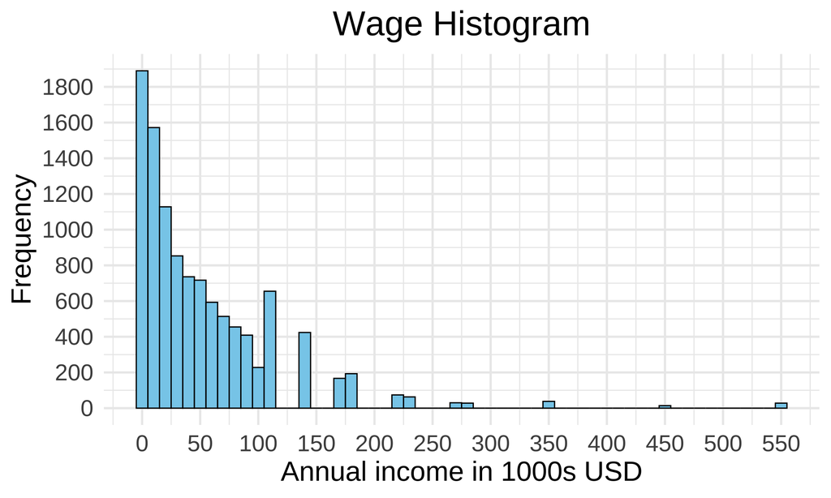

## 4.7 Data adjustment

```r
# Store mean and standard deviation for later rescaling
wage_mean <- attr(scale(data$wage), "scaled:center")
wage_sd <- attr(scale(data$wage), "scaled:scale")

# Initialize random seed for reproducibility
set.seed(123)

# Create a function for one-hot encoding
dummy <- dummyVars(" ~ .", data = data)

# Apply one-hot encoding to the dataset
data <- data.frame(predict(dummy, newdata = data))

# Normalize the "wage" column
data$wage <- scale(data$wage)

# Convert "wage" column to numeric type
data$wage <- as.numeric(data$wage)

# Initialize random seed for reproducibility
set.seed(39)

split  <- initial_split(data, prop = 0.7)
data_train  <- training(split)
data_test   <- testing(split)
```

Now that we have adjusted the data and split it in to training and testing data, let’s have a look at it.

```
## Training data: 69.99722 %
```

```
## Test data: 30.00278 %
```

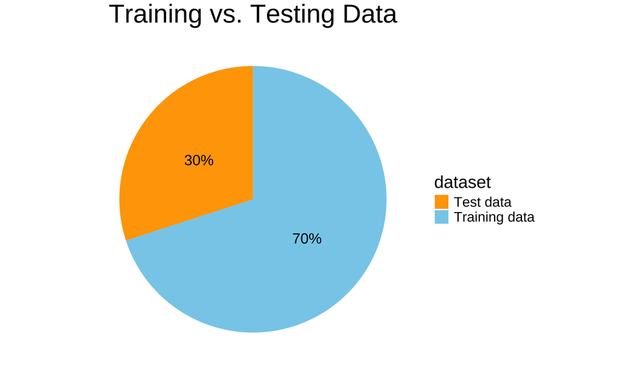

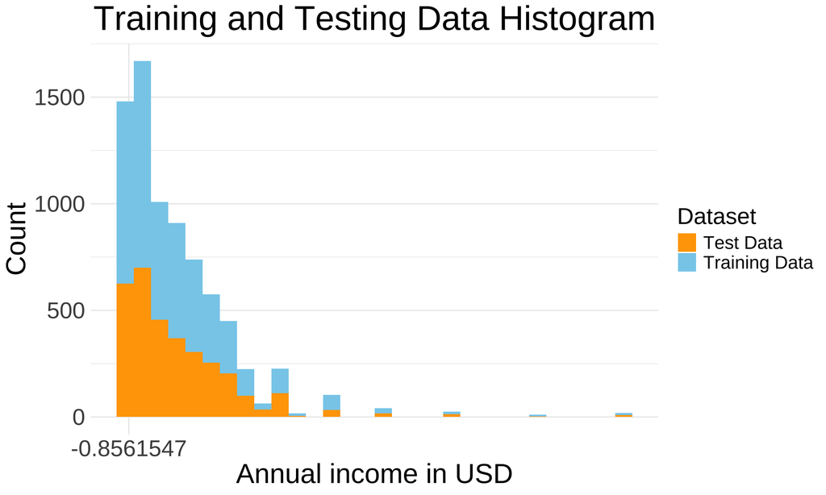

# 5 Using predictive models

Four wage prediction models were developed and trained, with the “Finding the best model” chapter dedicated to comparing their accuracy using Root Mean Square Error (RMSE). This comparison is critical because lower RMSE signifies better prediction – a crucial factor for any wage prediction model.

## 5.1 Linear regression

Our first model, a linear regression, excels at uncovering the relationship between a dependent variable (like the wage) and one or more independent variables (factors affecting the wage). It achieves this by fitting a linear equation to the data we have. Think of it as drawing a best-fitting straight line through all the data points. Each prediction is based on a weighted sum of these independent variables, where the weights are like dials we adjust during training to minimize the difference between the predicted and actual values. In simpler terms, the model learns the best combination of these factors to estimate wages accurately.

```r
# Linear regression model
linear <- lm(wage ~ ., data = data_train)

# Create prediction using linear regression
linear_prediction <- linear |> predict(data_test)
```

## 5.2 XGBoost

As our second model, Extreme Gradient Boosting (XGBoost) takes a different approach. It leverages a technique called gradient boosting, which essentially builds a series of decision trees one after another. Each new tree aims to correct the mistakes of the previous ones by focusing on the areas where the prior models struggled. It achieves this by employing a gradient descent algorithm, which helps it minimize the overall error in predictions. In simpler terms, XGBoost builds on the learnings from prior models to create an ensemble that is more accurate and robust.

```r
# XGBoost model
xgb <- xgboost(
  data = as.matrix(data_train[, -261]), # excluding the target variable
  label = data_train$wage,
  objective = "reg:squarederror",
  nrounds = 300,
  booster = "gbtree",
  objective = "reg:squarederror",
  eta = 0.1,
  max_depth = 5,
  min_child_weight = 1,
  subsample = 0.5,
  colsample_bytree = 0.5
)

# Create prediction using XGBoost
xgb_prediction <- predict(xgb, as.matrix(data_test[, -261]))

# XGBoost evaluation
xgb_mse <- mean((xgb_prediction - data_test$wage)^2)
xgb_rmse <- sqrt(xgb_mse)
```

## 5.3 SVM

For our third model, we turn to Support Vector Machines (SVMs). Unlike linear regression, SVMs don’t create a straight line to separate the data. Instead, they find the widest possible “gap” between the classes in our training data. This gap is called a hyperplane. While tuning SVMs to achieve the absolute best hyperplane can be very time-consuming, we opted for a less intensive approach in this project to balance training speed with good prediction results.

```r
# SVM model
svm <- svm(wage~ ., data = data_train, kernel = "linear", cost = 1)

# Create prediction using SVM
svm_prediction <- predict(svm, newdata = data_test)

# SVM evaluation
svm_mse <- mean((svm_prediction - data_test$wage)^2)
svm_rmse <- sqrt(svm_mse)
```

## 5.4 Neural Network

Our fourth model is a neural network. Inspired by the brain, it uses interconnected processing units to find hidden patterns in the data. Imagine tiny processors working together to unveil complex relationships, making neural networks powerful for wage prediction.

```r
# Specifying the grid values
grid <- expand.grid(.decay = c(0.5, 0.1), .size = c(5, 6, 7))

# Neural Network model
nn <- train(wage ~ ., data = data_train, method = "nnet", maxit = 20, tuneGrid = grid, trace = F, linout = 1, MaxNWts=2000)

# Create prediction using Neural Network
nn_prediction <- predict(nn, newdata = data_test)

# Neural Network evaluation
nn_mse <- mean((nn_prediction - data_test$wage)^2)
nn_rmse <- sqrt(nn_mse)
```

# 6 Finding the best model

```r
cat("Linear Regression model RMSE:", RMSE(linear_prediction, data_test$wage))
```

```
## Linear Regression model RMSE: 0.7210924
```

```r
cat("XGBoost model RMSE:", (xgb_rmse))
```

```
## XGBoost model RMSE: 0.7171971
```

```r
cat("SVM model RMSE:", (svm_rmse))
```

```
## SVM model RMSE: 0.7332711
```

```r
cat("Neural Network model RMSE:", (nn_rmse))
```

```
## Neural Network model RMSE: 0.7482145
```

## 6.1 Why Understanding Our Model Matters

Transparency in AI models, especially those impacting real-world decisions like wage prediction, is crucial. Understanding the factors influencing the model’s predictions fosters trust and allows stakeholders to identify potential biases. In our wage prediction model, interpretability helps guide policy decisions and improve data collection.

[figure not shown]

```r
# Extract feature importance from the model
importance_matrix <- xgb.importance(model = xgb)
importance_matrix <- importance_matrix[1:20,]  # Select the top 20 features

# Convert to data frame for the plot
importance_df <- as.data.frame(importance_matrix)

# Function to wrap text
wrap_it <- function(x, len = 20) {
  str_wrap(x, width = len)
}

# Apply text wrapping to the 'Feature' column
importance_df$Feature <- sapply(importance_df$Feature, wrap_it)

# Plot the feature importance with a gradient color theme using ggplot2
ggplot(importance_df, aes(x = reorder(Feature, Gain), y = Gain, fill = Gain)) +
  geom_bar(stat = "identity", color = "black") +
  scale_fill_gradient(low = "yellow", high = "red") +
  coord_flip() +
  theme_minimal() +
  theme(
    plot.title = element_text(hjust = 0.5, size = 20, face = "bold"),
    axis.title.x = element_text(size = 16, face = "bold"),
    axis.title.y = element_text(size = 16, face = "bold"),
    axis.text.x = element_text(size = 12, face = "bold"),
    axis.text.y = element_text(size = 12, face = "bold"),
    legend.position = "none"
  ) +
  labs(title = "Top 20 Feature Importance", x = "Features", y = "Relative Importance")
```

## 6.2 Feature Importance Unveils Key Drivers

Feature importance analysis, using the XGBoost library, sheds light on which variables hold the most weight in predicting wages. Here, we delve into the most impactful factors:

### 6.2.1 Country and Job Role

Being from the United States and working as a student are the most significant influences. This suggests potential income disparities across regions and job types.

### 6.2.2 Experience Matters

Features like “Models in production for more than 2 years” and experience categories for code and methods highlight the value of experience in wage determination.

### 6.2.3 Age and Location

Age groups consistently appear, indicating a correlation between age and predicted wages. Additionally, working in specific countries like Switzerland and India is influential. This information can be valuable for understanding wage variations across demographics and geographies.

### 6.2.4 Beyond Technical Skills

Features like “Reapplying machine learning to new areas” and “Personally improves my product or workflows” suggest a proactive and adaptable skillset can influence wages. This emphasizes the growing importance of soft skills in the workforce.

## 6.3 SHAP

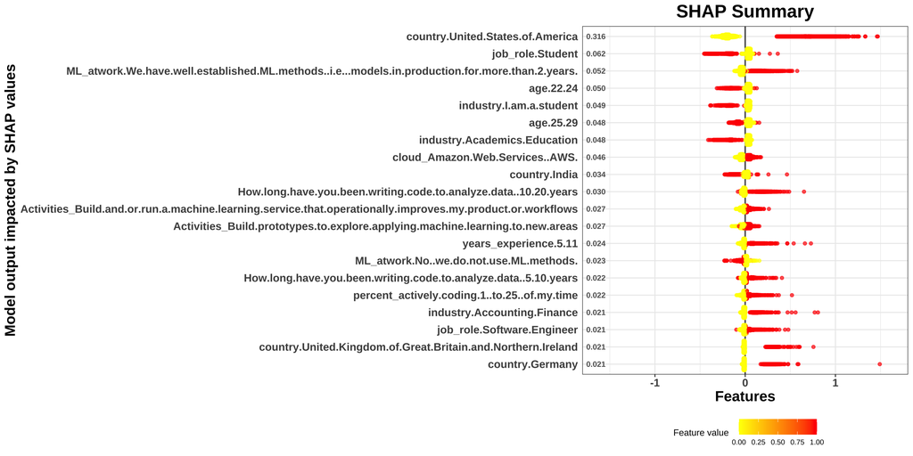

```r
# Convert data frames to matrices, excluding the last column 'wage'
Training_data_matrix <- data.matrix(data_train[, -ncol(data_train)])
Test_data_matrix <- data.matrix(data_test[, -ncol(data_test)])

# Calculate SHAP values for the training data using the xgboost model
shap_values <- shap.values(xgb_model = xgb, X_train = Training_data_matrix)
shap_contrib <- shap_values$shap_score

# Compute the mean absolute SHAP values for each feature
mean_abs_shap <- apply(shap_contrib, 2, function(x) mean(abs(x)))

# Select the indices of the top 20 features based on SHAP importance
top_20_indices <- order(mean_abs_shap, decreasing = TRUE)[1:20]
top_20_features <- colnames(Training_data_matrix)[top_20_indices]

# Filter SHAP contributions to include only the top 20 features
filtered_shap_contrib <- shap_contrib[, ..top_20_indices, drop = FALSE]

# Prepare data for the SHAP summary plot
shap_long <- shap.prep(shap_contrib = filtered_shap_contrib, X_train = Training_data_matrix[, top_20_indices, drop = FALSE])

# Generate and customize the SHAP summary plot for the top 20 features
shap.plot.summary(shap_long) +
  scale_color_gradient(low = "yellow", high = "red") +
  theme(
    plot.title = element_text(hjust = 0.5, size = 20, face = "bold"),
    axis.title.x = element_text(size = 16, face = "bold"),
    axis.title.y = element_text(size = 16, face = "bold"),
    axis.text.x = element_text(size = 12, face = "bold"),
    axis.text.y = element_text(size = 12, face = "bold")
  ) +
  labs(title = "SHAP Summary", x = "Model output impacted by SHAP values", y = "Features")
```

The SHAP summary plot offers a window into the model’s inner workings. Each dot on this visualization represents a feature’s influence on a specific wage prediction, with positive values (to the right) pushing the prediction higher and negative values (to the left) pulling it lower. The color gradient (Red to yellow) further reveals the feature’s value for that instance, with yellow indicating low and Red indicating high. This allows us to understand how different factors interact to shape the model’s predictions. Let’s take a look at the key drivers influencing our wage prediction.

Geographic Disparity “country_United.States.of.America” emerges as the top feature, highlighting potential income disparities across geographical regions. This finding warrants further investigation.

Industry and Experience The model considers industry (e.g., “industry_I.am.a.student”, “industry_Academics.Education”) and experience (“years_experience_5.11”) as significant factors.

Technical Background and Skills “cloud_Amazon.Web.Services.AWS” and activity-related features (“Activities_Build.prototypes”) suggest a technical background and specific activities can influence predictions.

# 7 Future wages

Predicting the future wages of our group members.

## 7.1 Loading and preparing the group members data

```r
# Prep
group_members_data <- read_excel("group-members_data.xlsx")

# Convert the new dataset to a matrix (excluding the target variable column, assuming it doesn't exist in new_data)
group_data_matrix <- as.matrix(group_members_data)
```

## 7.2 Function to make the prediction

```r
predicting_wage <- function(row_data, model_xgb, wage_sd, wage_mean, name) {
  row_matrix <- as.matrix(row_data)
  predicted_wage <- predict(xgb, row_matrix) * wage_sd + wage_mean
  cat("The predicted wage of", name, "is:", predicted_wage, "\n")
}
```

## 7.3 Our future wages predicted

```
## The predicted wage of Elia is: 38552.58
```

```
## The predicted wage of Fidan is: 13536.29
```

```
## The predicted wage of Lenny is: 47784.97
```

```
## The predicted wage of Sebastian is: 23428.6
```

```
## The predicted wage of Marc is: 38855.85
```